# IMDb top 1000 movies Analyzation

Róbert Vámosi

2022 03 14

Import the data from the working directory:

```r
imdb <- read.csv("imdb_top_1000.csv", encoding="UTF-8")
summary(imdb)
```

```
##  Poster_Link        Series_Title       Released_Year      Certificate
##  Length:1000        Length:1000        Length:1000        Length:1000
##  Class :character   Class :character   Class :character   Class :character
##  Mode  :character   Mode  :character   Mode  :character   Mode  :character
##
##
##
##
##    Runtime             Genre            IMDB_Rating      Overview
##  Length:1000        Length:1000        Min.   :7.600   Length:1000
##  Class :character   Class :character   1st Qu.:7.700   Class :character
##  Mode  :character   Mode  :character   Median :7.900   Mode  :character
##                                        Mean   :7.949
##                                        3rd Qu.:8.100
##                                        Max.   :9.300
##
##    Meta_score       Director            Star1              Star2
##  Min.   : 28.00   Length:1000        Length:1000        Length:1000
##  1st Qu.: 70.00   Class :character   Class :character   Class :character
##  Median : 79.00   Mode  :character   Mode  :character   Mode  :character
##  Mean   : 77.97
##  3rd Qu.: 87.00
##  Max.   :100.00
##  NA's   :157
##     Star3              Star4            No_of_Votes         Gross
##  Length:1000        Length:1000        Min.   :  25088   Length:1000
##  Class :character   Class :character   1st Qu.:  55526   Class :character
##  Mode  :character   Mode  :character   Median : 138549   Mode  :character
##                                        Mean   : 273693
##                                        3rd Qu.: 374161
##                                        Max.   :2343110
##
```

```r
head(imdb)
```

```
##                                                                                                                                         Poster_Link
## 1 https://m.media-amazon.com/images/M/MV5BMDFkYTc0MGEtZmNhMC00ZDIzLWFmNTEtODM1ZmRlYWMwMWFmXkEyXkFqcGdeQXVyMTMxODk2OTU@._V1_UX67_CR0,0,67,98_AL_.jpg
## 2 https://m.media-amazon.com/images/M/MV5BM2MyNjYxNmUtYTAwNi00MTYxLWJmNWYtYzZlODY3ZTk3OTFlXkEyXkFqcGdeQXVyNzkwMjQ5NzM@._V1_UY98_CR1,0,67,98_AL_.jpg
## 3                                 https://m.media-amazon.com/images/M/MV5BMTMxNTMwODM0NF5BMl5BanBnXkFtZTcwODAyMTk2Mw@@._V1_UX67_CR0,0,67,98_AL_.jpg
## 4 https://m.media-amazon.com/images/M/MV5BMWMwMGQzZTItY2JlNC00OWZiLWIyMDctNDk2ZDQ2YjRjMWQ0XkEyXkFqcGdeQXVyNzkwMjQ5NzM@._V1_UY98_CR1,0,67,98_AL_.jpg
## 5 https://m.media-amazon.com/images/M/MV5BMWU4N2FjNzYtNTVkNC00NzQ0LTg0MjAtYTJlMjFhNGUxZDFmXkEyXkFqcGdeQXVyNjc1NTYyMjg@._V1_UX67_CR0,0,67,98_AL_.jpg
## 6 https://m.media-amazon.com/images/M/MV5BNzA5ZDNlZWMtM2NhNS00NDJjLTk4NDItYTRmY2EwMWZlMTY3XkEyXkFqcGdeQXVyNzkwMjQ5NzM@._V1_UX67_CR0,0,67,98_AL_.jpg
##                                    Series_Title Released_Year Certificate
## 1                      The Shawshank Redemption          1994           A
## 2                                 The Godfather          1972           A
## 3                               The Dark Knight          2008          UA
## 4                        The Godfather: Part II          1974           A
## 5                                  12 Angry Men          1957           U
## 6 The Lord of the Rings: The Return of the King          2003           U
##   Runtime                    Genre IMDB_Rating
```

[output cut: 27 more lines]

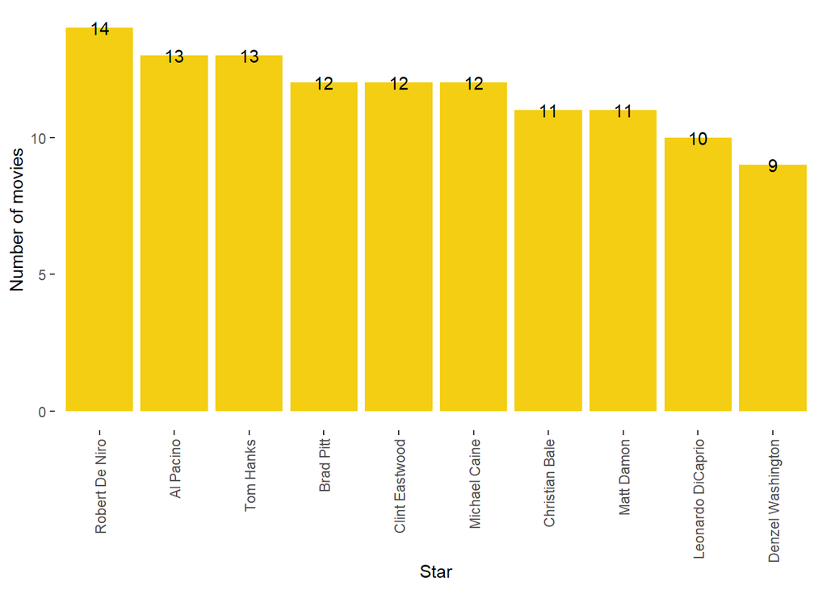

```r
star1 <- as.data.frame(imdb$Star1)
star2 <- as.data.frame(imdb$Star2)
star3 <- as.data.frame(imdb$Star4)
star4 <- as.data.frame(imdb$Star4)

colnames(star1) <- c("star")
colnames(star2) <- c("star")
colnames(star3) <- c("star")
colnames(star4) <- c("star")


stars <- rbind(star1, star2, star3, star4)

stars_c <- count(stars, star)

stars_c <- head(arrange(stars_c, desc(n)), 10)

stars_c %>% ggplot(aes(reorder(star, -n), n)) + geom_bar(stat="identity", fill="#F3CE13") + theme(axis.text.x = element_text(angle = 90, vjust = 0.5, hjust=1)) + theme(panel.background = element_blank()) + geom_text(aes(label=n)) + xlab("Star") + ylab("Number of movies")
```

Check the most succesful directors:

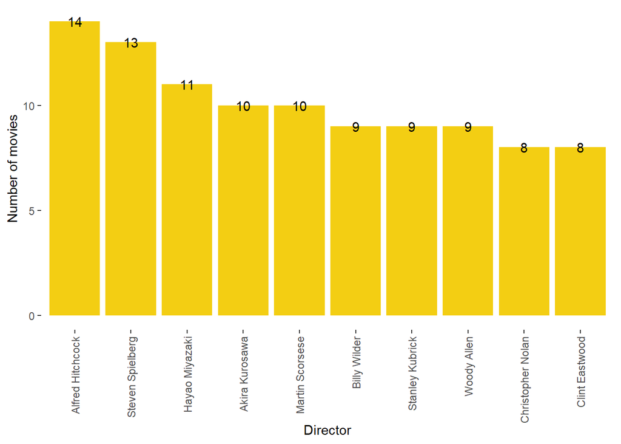

```r
directors <- as.data.frame(imdb$Director)
colnames(directors) <- c("director")
top_directors <- head(arrange(count(directors, director), desc(n)), 10)

top_directors %>% ggplot(aes(reorder(director, -n), n)) + geom_bar(stat="identity", fill="#F3CE13") + theme(axis.text.x = element_text(angle = 90, vjust = 0.5, hjust=1)) + theme(panel.background = element_blank()) + geom_text(aes(label=n)) + xlab("Director") + ylab("Number of movies")
```

Check genres which are the most likely to get into imdb top 1000:

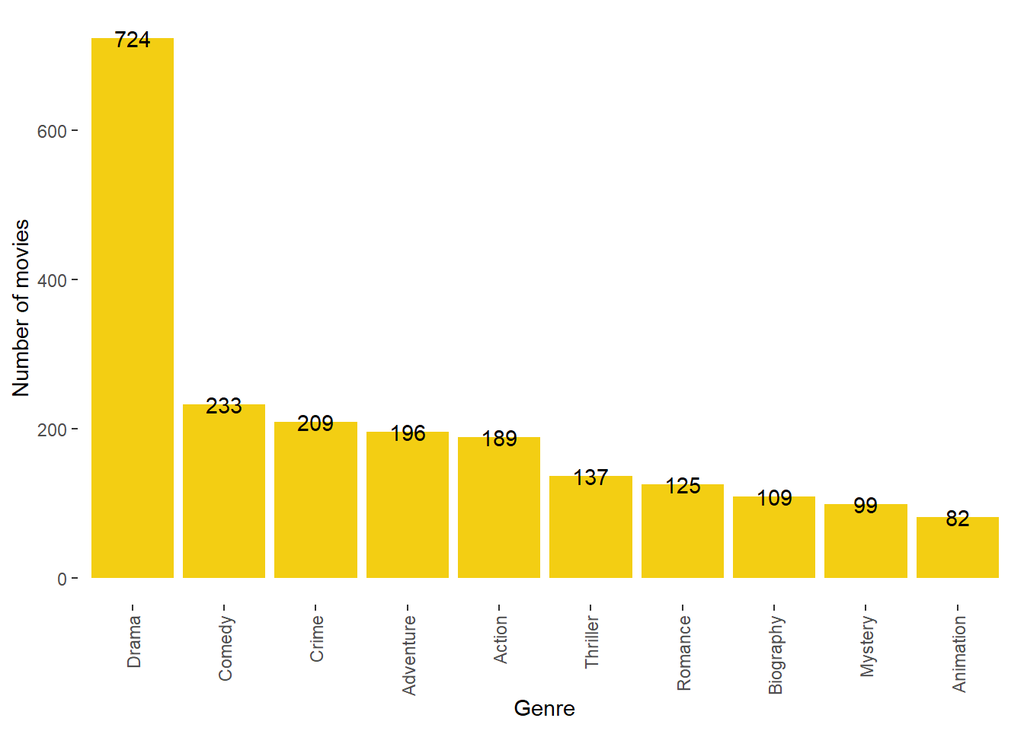

```r
library(stringr)

genres <- as.data.frame(str_split_fixed(imdb$Genre, ", ", 3))

genres_1 <- as.data.frame(genres$V1)
genres_2 <- as.data.frame(genres$V2)
genres_3 <- as.data.frame(genres$V3)

colnames(genres_1) <- c("genre")
colnames(genres_2) <- c("genre")
colnames(genres_3) <- c("genre")

genres_r <- rbind(genres_1, genres_2, genres_3)

genres_plot <- head(arrange(count(genres_r, genre), desc(n)), 11)

genres_plot <- genres_plot[-c(2), ]

genres_plot %>% ggplot(aes(reorder(genre, -n), n)) + geom_bar(stat="identity", fill="#F3CE13") + theme(axis.text.x = element_text(angle = 90, vjust = 0.5, hjust=1)) + theme(panel.background = element_blank()) + geom_text(aes(label=n)) + xlab("Genre") + ylab("Number of movies")
```

Which certificate has the highest mean of IMDb score?

[figure not shown]

```r
imdb %>% group_by(Certificate) %>% summarise(m_score = mean(IMDB_Rating)) %>% ggplot(aes(reorder(Certificate, -m_score), m_score)) + geom_bar(stat="identity", fill="#F3CE13") + theme(axis.text.x = element_text(angle = 90, vjust = 0.5, hjust=1)) + theme(panel.background = element_blank()) + geom_text(aes(label=m_score), angle = 90) + xlab("Certificate") + ylab("Means of IMDb ratings")
```

First step to make the variables into a right format. Numbers in imdb$Gross have commas and in a character format so we need to change that:

```r
imdb$Gross <- as.numeric(gsub(",","",imdb$Gross))
imdb$Gross
```

```
##    [1]  28341469 134966411 534858444  57300000   4360000 377845905 107928762
##    [8]  96898818 292576195  37030102 315544750 330252182   6100000 342551365
##   [15] 171479930  46836394 290475067 112000000        NA  53367844        NA
##   [22] 188020017   7563397  10055859 216540909 136801374  57598247 100125643
##   [29] 130742922 322740140        NA    269061        NA 335451311  13092000
##   [36]  13182281  53089891 132384315  32572577 187705427   6719864  23341568
##   [43]  19501238 422783777 204843350  11990401        NA 210609762   5321508
##   [50]  32000000   1024560    163245     19181   1661096        NA        NA
##   [57]   5017246  12391761 190241310 858373000 678815482 209726015 162805434
##   [64] 448139099   6532908   1223869 223808164  11286112    707481  25544867
##   [71]   2375308   5321508 248159971  44017374  83471511  78900000        NA
##   [78]        NA    275902   8175000        NA  36764313        NA    288475
##   [85] 159227644        NA   1373943        NA    687185   7098492   6857096
##   [92]        NA        NA 120540719  34400301  33225499  30328156   3635482
##   [99] 130096601 138433435    933933 191796233  75600000   2832029  46357676
```

[output cut: 128 more lines]

imdb$Runtime in a character format too and all observations have the " min" part. We should remove that:

```r
imdb$Runtime <- str_sub(imdb$Runtime, end=-5)

imdb$Runtime <- as.numeric(imdb$Runtime)

imdb$Runtime
```

```
##    [1] 142 175 152 202  96 201 154 195 148 139 178 142 161 179 136 146 124 133
##   [19] 160 132 153 169 130 125 169 189 116 127 118 121 133 207 130 122 106 112
##   [37] 130 151 150 155 119 106 110  88 137 155  89 116 165 109 102  87  87 126
##   [55] 125 147 106 161 117 181 149 105 165 164 170 165  98 137 101 113 134 229
##   [73] 115 146 147 117 122 143  95 116  88 112 110 125 119 104 139 160 115 123
##   [91] 131 132 112 153 108 122 104 102 122 126  89  81 178  99 116 142 137 160
##  [109] 170 131 149 114 129 136 149 132 228 125 136 128 103 143  89 107 119 117
##  [127] 153  68 143 138 156 130 115 132 167  96 163 146  87 186 321 134 135 129
##  [145] 140 138  96 180 153 158 118 103 132 167 122 140 210 156 119 135 156 107
##  [163] 138 128 170 178 160 130 127 142  86 132 162 129 162  99 177 204  91 172
##  [181] 129 110 179 121  91  96 118 105 136  88 138 126  99  95  45 122 136 130
##  [199] 106 145 139 160 137 118 122 100 196 153 125  99 149 117 139  95 151 134
##  [217] 123 152 129  93 122 155 153 120 104 116 130 130  93  92  98 148 122 144
##  [235] 132 121 140  80 156 131 183 111 100 141 154  92  87 224 107 169 103 127
##  [253] 117  98  93  98 170  98 189 101  99 102 127 133 171 125 128  89 120 145
```

[output cut: 41 more lines]

Change imdb$Released_Year to numeric format:

```r
imdb$Released_Year <- as.numeric(imdb$Released_Year)
imdb$Released_Year
```

```
##    [1] 1994 1972 2008 1974 1957 2003 1994 1993 2010 1999 2001 1994 1966 2002
##   [15] 1999 1990 1980 1975 2020 2019 2020 2014 2002 2001 1998 1999 1997 1995
##   [29] 1991 1977 1962 1954 1946 2019 2014 2011 2006 2006 2002 2000 1998 1995
##   [43] 1994 1994 1991 1988 1988 1985 1968 1960 1942 1936 1931 2018 2017 2017
##   [57] 2016 2016 2018 2019 2018 2017 2012 2012 2009 2007 2008 2006 2003 2000
##   [71] 1997 1984 1981 1980 1979 1979 1971 1963 1964 1957 1957 1954 1950 1940
##   [85] 2019 2018 2018 2013 2012 2011 2010 2019 2005 2009 2004 2001 2000 2000
##   [99] 1999 1997 1997 1995 1995 1992 1987 1985 1986 1984 1983 1983 1981 1976
##  [113] 1973 1971 1968 1965 1962 1960 1959 1958 1952 1952 1948 1944 1941 1931
##  [127] 1927 1921 2019 2018 2018 2018 2017 2015 2017 2019 2015 2013 2013 2013
##  [141] 2012 2010 2012 2009 2011 2010 2009 2013 2007 2007 2006 2010 2005 2006
##  [155] 2005 2005 2004 2004 2004 2001 2000 1998 1997 1996 1995 1995 1994 1992
##  [169] 1989 1988 1988 1988 1985 1980 1979 1978 1976 1975 1975 1963 1962 1961
##  [183] 1961 1959 1957 1957 1955 1954 1953 1950 1950 1948 1942 1925 1924 2019
##  [197] 2016 2016 2016 2016 2014 2014 2017 2015 2014 2020 2014 2014 2012 2014
```

[output cut: 57 more lines]

We build a model where output variable is IMDB_Rating and input variables are Released_Year, Meta_score, Runtime and Gross.

```r
model <- glm(IMDB_Rating ~ Released_Year + Meta_score + Runtime + Gross,
             data = imdb,
             family = ("gaussian"))
```

Residuals vs Fitted plot shows that accurancy quite equal in the middle range and with extreme values too. In the Normal Q-Q plot we can see that the dots on the fitted line except on the top area but we have no big skew in this model. You can see on the Scale-location plot there are a minimal skew in the model because dots are randomly spread out. On the residuals vs leverage plot we cannot see a lot of outliers so probably our model won’t be misled by outliers.

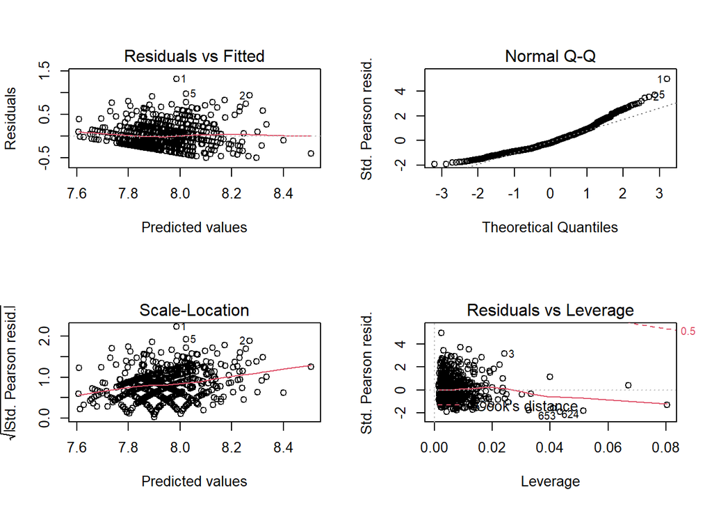

```r
par(mfrow = c(2,2))

plot(model)
```

Calling summary on model we can se that our model doesn’t work very well. Distance between null deviance and residual deviance is low, no one variable has a big effect on the output.

```r
summary(model)
```

```
##
## Call:
## glm(formula = IMDB_Rating ~ Released_Year + Meta_score + Runtime +
##     Gross, family = ("gaussian"), data = imdb)
##
## Deviance Residuals:
##     Min       1Q   Median       3Q      Max
## -0.5015  -0.1893  -0.0576   0.1354   1.3133
##
## Coefficients:
##                 Estimate Std. Error t value Pr(>|t|)
## (Intercept)    1.117e+01  1.089e+00  10.260  < 2e-16 ***
## Released_Year -2.020e-03  5.346e-04  -3.779 0.000170 ***
## Meta_score     5.732e-03  8.108e-04   7.070 3.58e-12 ***
## Runtime        2.665e-03  3.761e-04   7.086 3.22e-12 ***
## Gross          3.259e-10  8.896e-11   3.664 0.000266 ***
## ---
## Signif. codes:  0 '***' 0.001 '**' 0.01 '*' 0.05 '.' 0.1 ' ' 1
##
## (Dispersion parameter for gaussian family taken to be 0.06947654)
##
##     Null deviance: 62.489  on 748  degrees of freedom
## Residual deviance: 51.691  on 744  degrees of freedom
##   (251 observations deleted due to missingness)
## AIC: 135.15
##
## Number of Fisher Scoring iterations: 2
```

Calling avPlots (by using car package) we can be sure that we have a quite meaningless model.

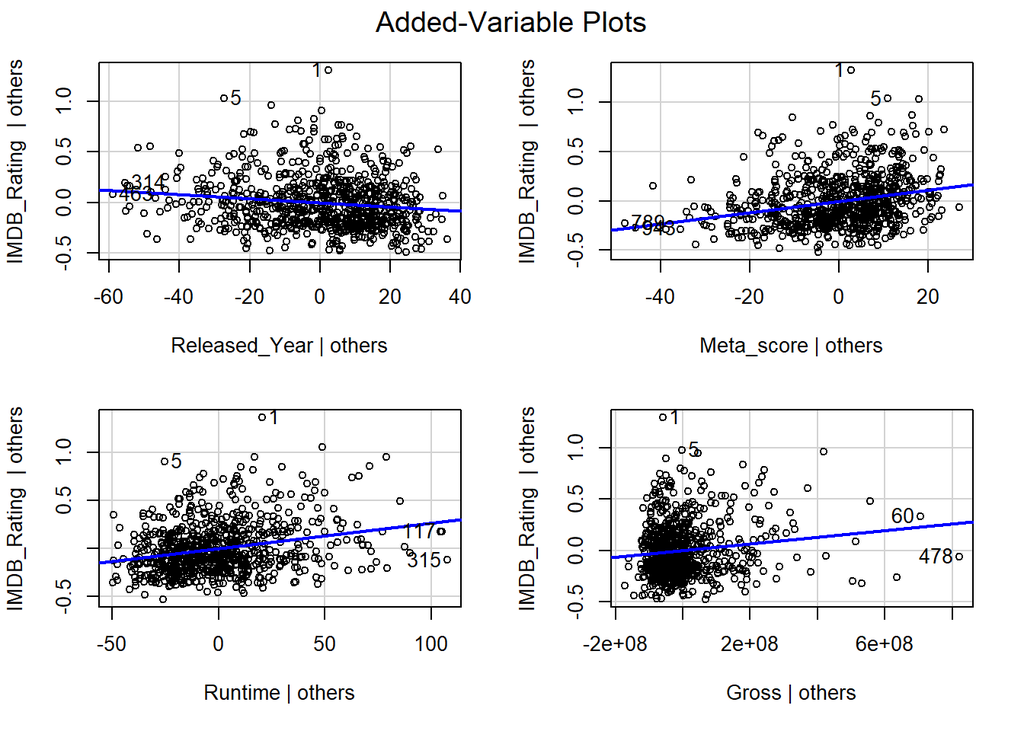

```r
avPlots(model)
```